# Model Selection and Boosting

### Introduction

Lets attempt to answer these questions:

1. How to deal with the bias variance tradeoff when building a model and evaluating its performance ?
2. How to choose the optimal values for the hyperparameters (the parameters that are not learned) ?
3. How to find the most appropriate Machine Learning model for my business problem?

To answer these questions, lwe will explore:

1. k-Fold Cross Validation
2. Grid Search

### K-Fold Cross Validation

To improve model performance, we use model selection techniques that consists of choosing the best parameters. Every time you build a machine learning model, there are 2 types of parameters:

- parameters the model learned - the parameters that were found and changed by running the model
- parameters that we chose like the kernal parameter in the kernal SVM model; these are the hyperparameters (grid search)

To evalaute model performace, use K-Fold Cross Validation to reduce the variance among test sets.

We wil reuse the kernal SVM model we have already built and apply K-Fold Cross Validation. (This is the one that help determine if a user will click on an add - yes or no.)

```r
# Importing the dataset
dataset = read.csv('./data/Social_Network_Ads.csv')
dataset = dataset[3:5]

# Encoding the target feature as factor
dataset$Purchased = factor(dataset$Purchased, levels = c(0, 1))

# Splitting the dataset into the Training set and Test set (caTools)
# install.packages('caTools')
split = sample.split(dataset$Purchased, SplitRatio = 0.75)
training_set = subset(dataset, split == TRUE)
test_set = subset(dataset, split == FALSE)

# Feature Scaling
training_set[-3] = scale(training_set[-3])
test_set[-3] = scale(test_set[-3])

# Fitting Kernel SVM to the Training set (e1071)
classifier = svm(formula = Purchased ~ ., data = training_set,
            type = 'C-classification', kernel = 'radial')

# Predicting the Test set results
y_pred = predict(classifier, newdata = test_set[-3])

# Making the Confusion Matrix
cm = addmargins(table(test_set[, 3], y_pred))
cm
```

```
##      y_pred
##         0   1 Sum
##   0    57   7  64
##   1     6  30  36
##   Sum  63  37 100
```

```r
cm = prop.table(table(test_set[, 3], y_pred))
cm
```

```
##    y_pred
##        0    1
##   0 0.57 0.07
##   1 0.06 0.30
```

```r
# Applying k-Fold Cross Validation (caret)
folds = createFolds(training_set$Purchased, k = 10)#always use the dependent variable
cv = lapply(folds, function(x) {
  training_fold = training_set[-x, ]#all the data except for fold x
  test_fold = training_set[x, ]
  classifier = svm(formula = Purchased ~ ., data = training_fold,
              type = 'C-classification', kernel = 'radial')
  y_pred = predict(classifier, newdata = test_fold[-3])
  cm = table(test_fold[, 3], y_pred)
  accuracy = (cm[1,1] + cm[2,2]) / (cm[1,1] + cm[2,2] + cm[1,2] + cm[2,1])
  return(accuracy)
})
cv
```

```
## $Fold01
## [1] 0.9
##
## $Fold02
## [1] 0.9333333
##
## $Fold03
## [1] 0.9333333
##
## $Fold04
## [1] 1
##
## $Fold05
## [1] 0.9032258
##
## $Fold06
## [1] 0.9677419
##
## $Fold07
## [1] 0.8666667
##
## $Fold08
## [1] 0.862069
##
## $Fold09
## [1] 0.9310345
##
## $Fold10
## [1] 0.9333333
```

```r
accuracy = mean(as.numeric(cv))
accuracy#This has much higher confidence than basing a decision of one training set
```

```
## [1] 0.9230738
```

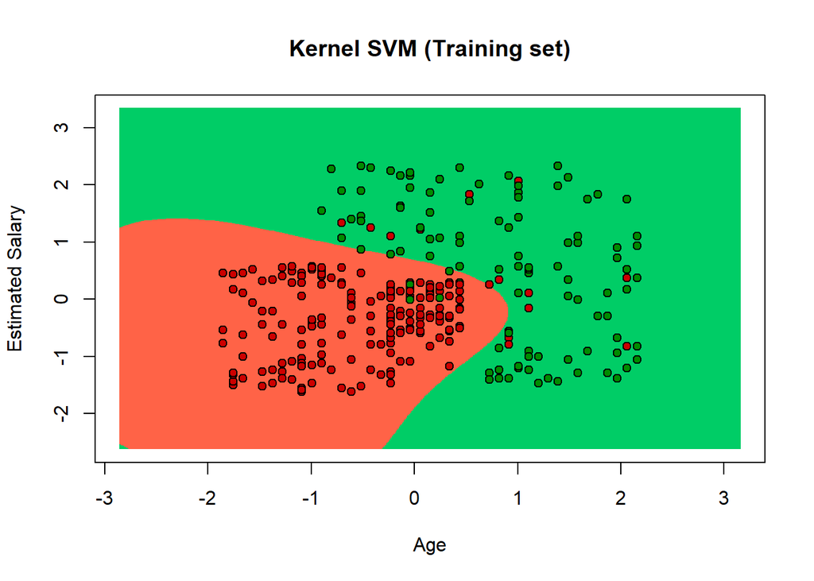

```r
# Visualizing the Training set results
library(ElemStatLearn)
set = training_set
X1 = seq(min(set[, 1]) - 1, max(set[, 1]) + 1, by = 0.01)
X2 = seq(min(set[, 2]) - 1, max(set[, 2]) + 1, by = 0.01)
grid_set = expand.grid(X1, X2)
colnames(grid_set) = c('Age', 'EstimatedSalary')
y_grid = predict(classifier, newdata = grid_set)
plot(set[, -3],
     main = 'Kernel SVM (Training set)',
     xlab = 'Age', ylab = 'Estimated Salary',
     xlim = range(X1), ylim = range(X2))
contour(X1, X2, matrix(as.numeric(y_grid), length(X1), length(X2)), add = TRUE)
points(grid_set, pch = '.', col = ifelse(y_grid == 1, 'springgreen3', 'tomato'))
points(set, pch = 21, bg = ifelse(set[, 3] == 1, 'green4', 'red3'))
```

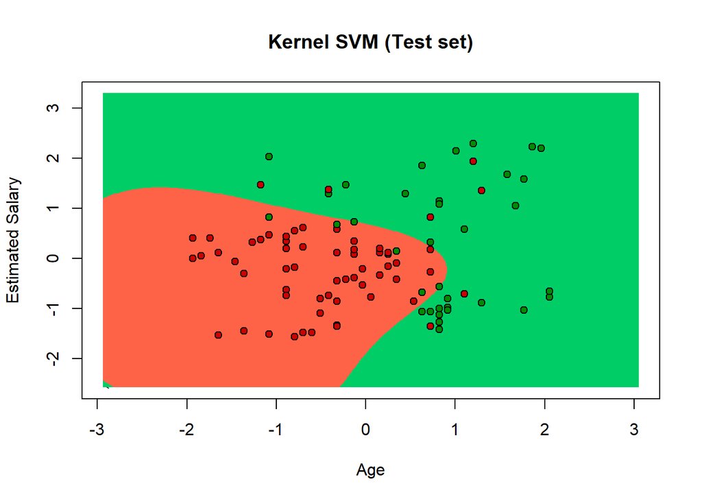

```r
# Visualizing the Test set results
library(ElemStatLearn)
set = test_set
X1 = seq(min(set[, 1]) - 1, max(set[, 1]) + 1, by = 0.01)
X2 = seq(min(set[, 2]) - 1, max(set[, 2]) + 1, by = 0.01)
grid_set = expand.grid(X1, X2)
colnames(grid_set) = c('Age', 'EstimatedSalary')
y_grid = predict(classifier, newdata = grid_set)
plot(set[, -3], main = 'Kernel SVM (Test set)',
     xlab = 'Age', ylab = 'Estimated Salary',
     xlim = range(X1), ylim = range(X2))
contour(X1, X2, matrix(as.numeric(y_grid), length(X1), length(X2)), add = TRUE)
points(grid_set, pch = '.', col = ifelse(y_grid == 1, 'springgreen3', 'tomato'))
points(set, pch = 21, bg = ifelse(set[, 3] == 1, 'green4', 'red3'))
```